[figure not shown]

Software 0.7.0

# Retinal Review Workbench

One retinal image→reviewed dataset

Clinician-led retinal review and dataset preparation

Research and clinical-support proof of concept · public and synthetic data · human review remains authoritative

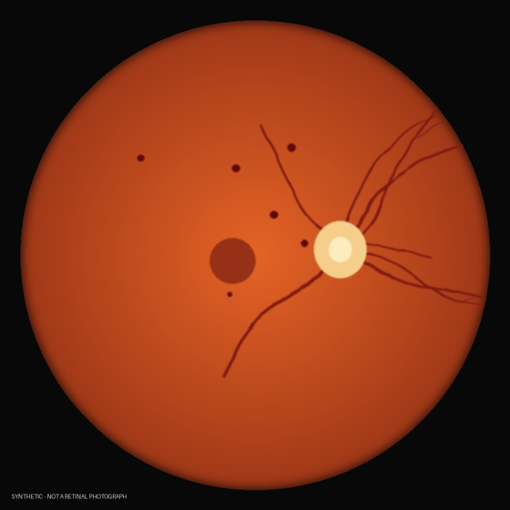

manifest.jsonimages.csvannotations.csv

Synthetic drawing, not a retinal photograph

02One case arrives

## One retinal image enters a *controlled* review workflow.

The Worklist shows every admitted image with its patient and eye context, AI result, and review status.

**Admitted, hashed, immutable.** The source file is never moved or rewritten.

**Nothing is inferred silently.** Patient and eye stay unlinked until a reviewer confirms them.

127.0.0.1:8000/app/#/worklist

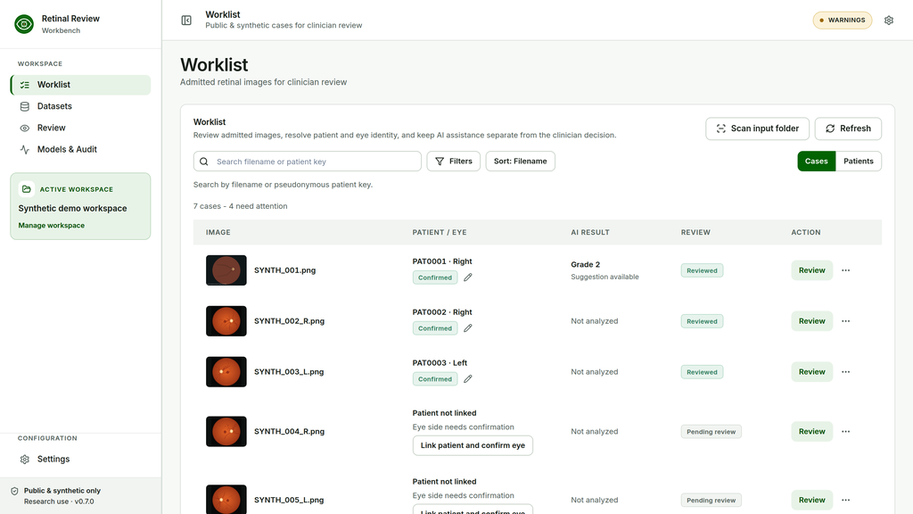

Real v0.7.0 Worklist with synthetic cases.

03Three human decisions

## Every case passes *three explicit* confirmation boundaries.

MILESTONE 1

### Confirm Image

Is this the right image, patient key, and eye?

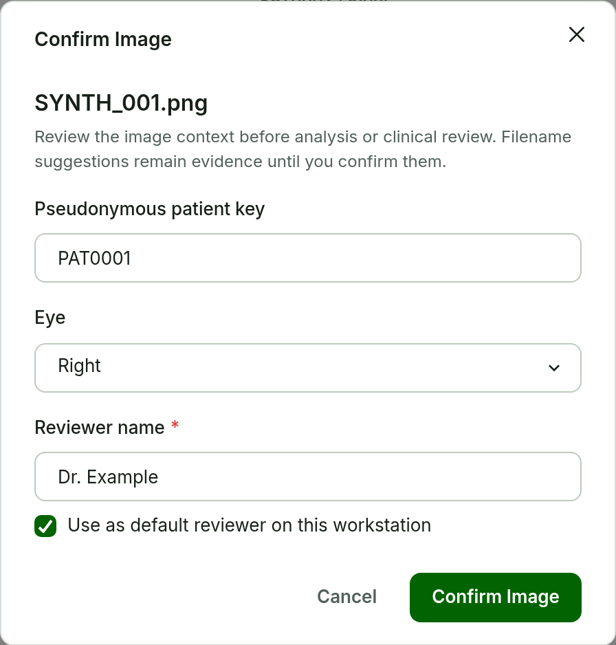

→

MILESTONE 2

### Confirm DR Grade

What is the clinician's final DR grade?

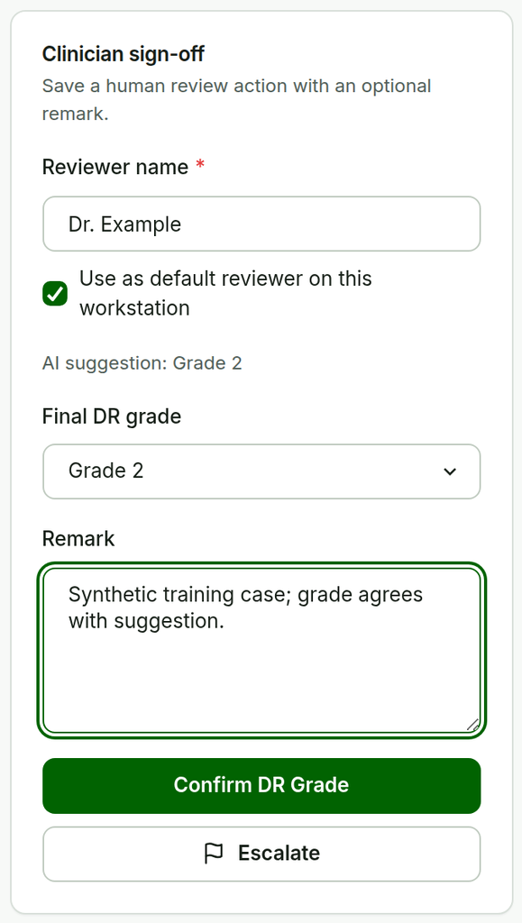

→

MILESTONE 3

### Confirm Annotation

Has the active annotation set been reviewed, at this hash?

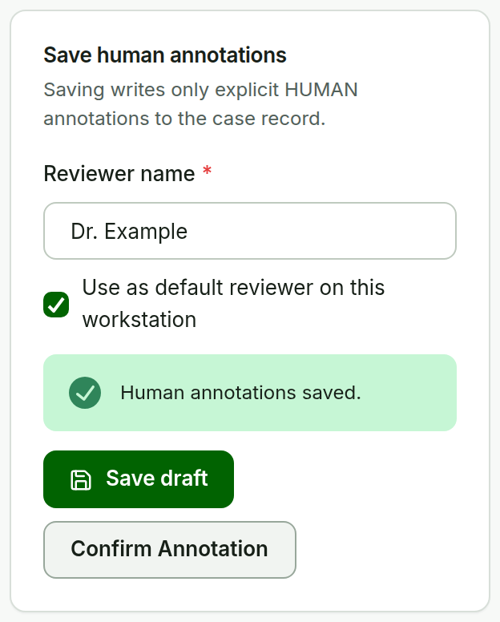

**No per-lesion queue.** AI suggestions never need to be accepted or rejected one by one.

04AI assists, human decides

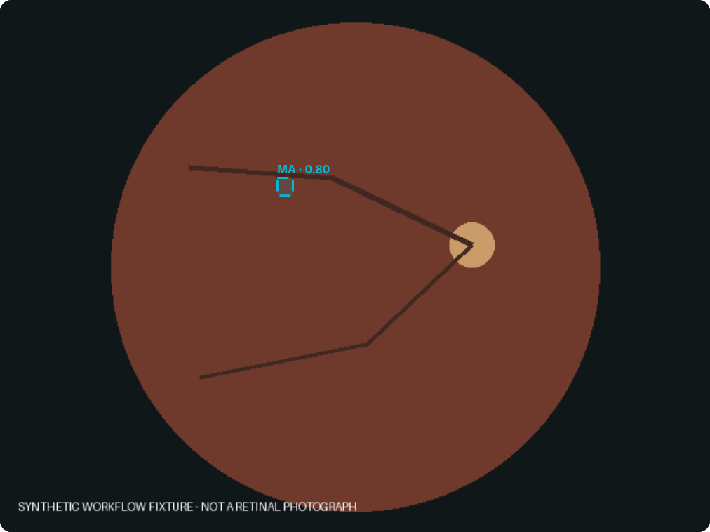

1

### RETFound grade suggestion

Optional model evidence · a model score, not a calibrated probability

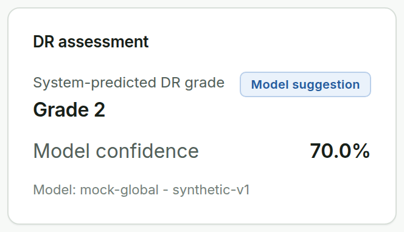

2

### PRISM lesion ROIs

Optional overlays · an empty result never proves absence

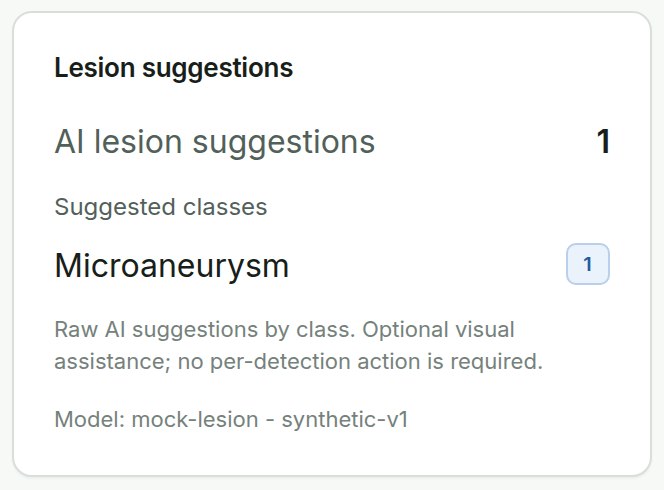

3

### Clinician final decision

Confirm DR Grade records the human grade as the authoritative decision.

Model evidence is optionalHuman review remains authoritative

05Correct AI only when needed

## Fix one ROI. *Keep* the original AI evidence.

AI ROI

[figure not shown]

**Microaneurysm · 0.80**

→

Select · popover

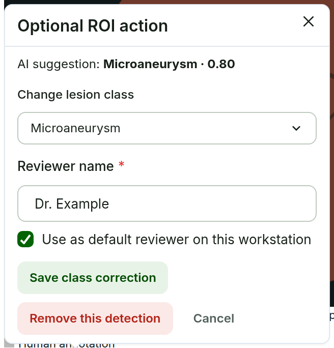

→

Class correction

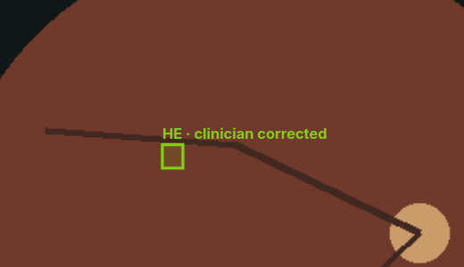

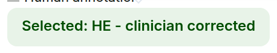

**Hemorrhage** · clinician corrected

**Preserved for audit:** original class, score, geometry, model, and detection identity. Removal is also available and equally auditable.

**Never displayed:** Hemorrhage · 0.80 — the score belongs to the class the model predicted.

06Built for repeated review

## Less repetitive work, *without silently changing* clinical state.

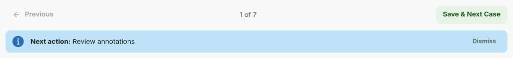

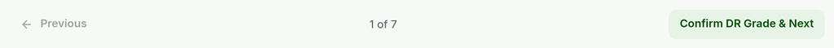

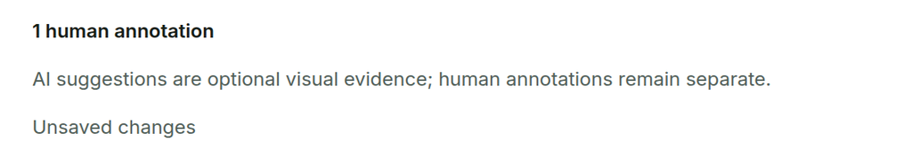

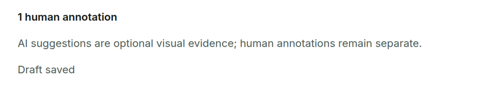

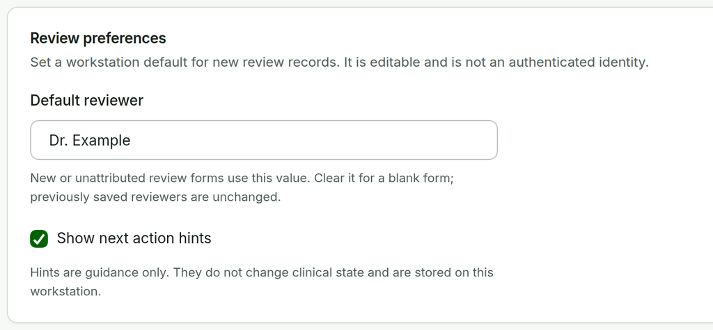

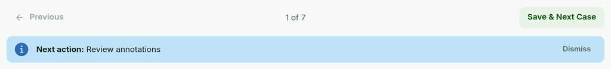

You have unsaved annotation changes. Leave this case?

CancelOK

Browser confirmation shown by the Annotation Editor while a draft is unsaved, saving, or failed.

01

### Previous / Next

Moves through the case order; never saves or confirms.

02

### Save & Next

Saves the draft or confirms the grade, then opens the next case.

03

### Autosave draft

Unsaved changes → Draft saved, about a second after editing stops.

04

### Default reviewer

Browser-local convenience; editable, not authentication.

05

### Next action

Quiet guidance only; it never changes case state.

06

### Unsaved changes guard

Leaving with unsaved edits asks first.

07Review becomes data

## Classification readiness *≠* lesion annotation readiness.

DR-readyDR: Ready

DR-grade task

- Valid source provenance
- Included fundus image
- Final clinician grade, reviewer, and time

≠

Lesion-readyLesions: Ready

Lesion-annotation task

- Valid source provenance
- Included fundus image
- Confirm Annotation matching the active set hash

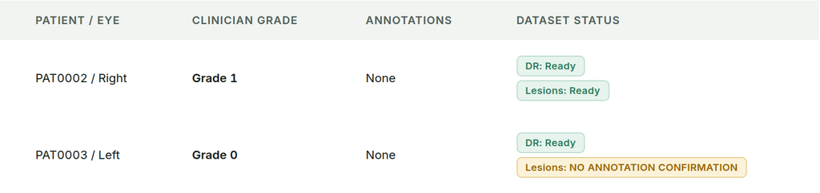

**One task can be ready while the other is not.** PAT0003 has a final grade but no annotation confirmation, so it exports as DR-ready only.

08Traceability

## Every exported record traces back to its *source*.

### Source image

Admitted once, hashed, never modified.

source SHA-256

### Analysis

Derived analysis image with its own identity and coordinate mapping.

analysis SHA-256

### Model evidence

Model ID, revision, raw output, and score kept exactly as returned.

retfound-aptos5 · prism-dr-5fold

### Clinician decision / correction

Human grade, corrections, and removals recorded beside the AI evidence.

reviewer · time · hash

### Dataset manifest

Task-specific readiness and provenance in the export.

s4.dataset-manifest.v2

**Original AI evidence stays auditable**Class, score, geometry, and provenance are never overwritten.

**Human correction stays distinct**Corrected, human-authored, removed, and CVAT-imported states remain separate.

**Identity stays traceable**Source and analysis identities link the export to the admitted image.

09Deployment

## Review on the workstation. Models on the *hospital GPU host*.

Clinician

### Workstation

Review app at /app/ · local Workspace · export

APP_PROFILE=review

Network

### Protected hospital LAN

Firewall and TLS at the boundary · no public exposure

Contract

### Provider-neutral Model API

/health · /v1/models · predict routes

REMOTE_MODEL_URL

Server

### Hospital GPU host

CUDA · one worker · systemd

APP_PROFILE=model_api

Assets

### Verified RETFound + PRISM

Pinned revisions and SHA-256 · fail closed

**Online setup once**setup.sh acquires, verifies, and prints READY

**Offline-safe normal startup**start.sh verifies local assets and never downloads

**CVAT optional**Dense annotation only; not needed for review or export

10Live demo

## Now let's review one case.

Worklist*→*Confirm Image*→*Review*→* Confirm DR Grade*→*Edit one ROI*→*Confirm Annotation*→*Dataset

Switch to the workstation at 127.0.0.1:8000/app/ with the synthetic Workspace.

Retinal Review Workbench 0.7.0 · research and clinical-support proof of concept · no autonomous diagnosis or referral

← → / Space · Home / End · F fullscreen